# **Act Report**

1. A general visualization of the dataset
2. A bar graph displaying the most popular dog breed
3. A scatter plot comparing retweet count to favorite count
4. A pie chart visualizing the breakdown of ratings

```python
import pandas as pd
import numpy as np
import requests
import tweepy
import json
import time
import os
import matplotlib.pyplot as plt
import seaborn as sns
import re
import warnings

%matplotlib inline
```

```python
tec_df = pd.read_csv('twitter_archive_master.csv')
```

### General Visualization

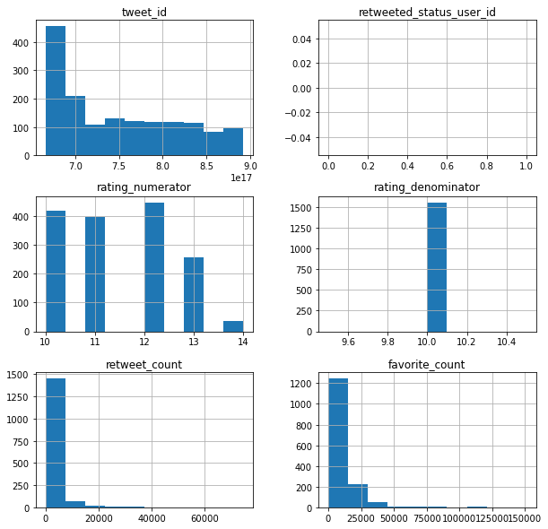

```python
# histogram
tec_df.hist(figsize = (10,10));
```

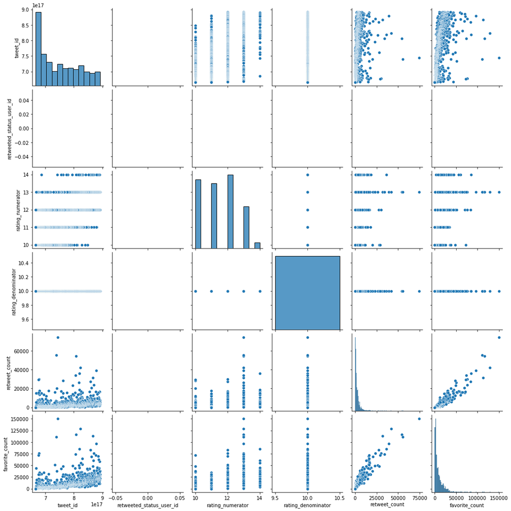

```python
# scatter plots
gen_scat = sns.pairplot(tec_df)
```

### Focused Visualization A: Most Popular Dog Breed (Bar Graph)

*What is the most popular dog breed?*

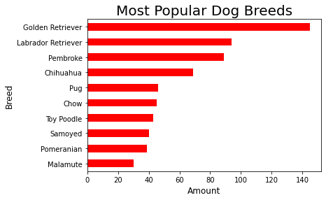

```python
pop_breeds = tec_df['dog_breed'].value_counts()[0:10].sort_values(axis = 0, ascending = True)
pop_breeds.plot(kind = 'barh', color = ['red'])
plt.title('Most Popular Dog Breeds', size = 20)
plt.xlabel('Amount', size = 12)
plt.ylabel('Breed', size = 12)
plt.savefig('pop_breeds.jpg')
```

### Focused Visualization B: Retweets vs Favorites (Scatter Plot)

*How correlated are tweets that have been retweeted and tweets that have favorited*

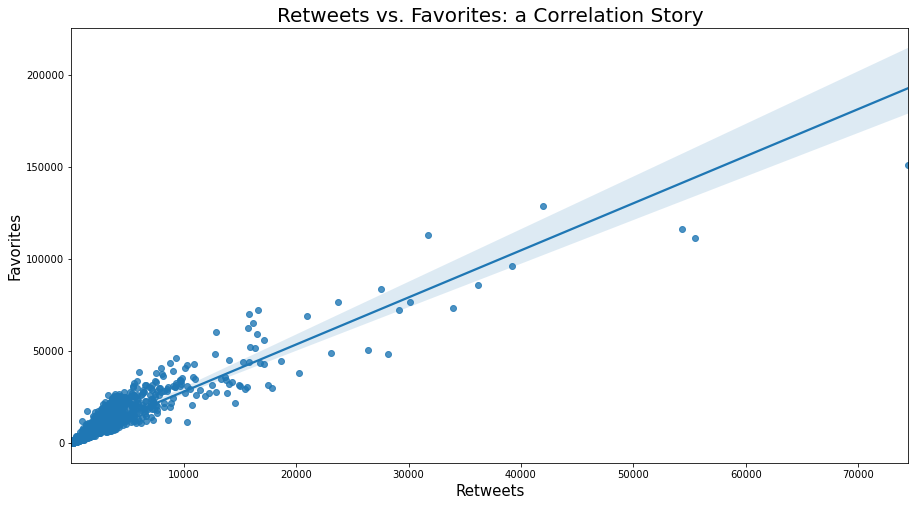

```python
# creating a seaborn regplot
plt.figure(figsize = (15,8))
plt.title('Retweets vs. Favorites: a Correlation Story', size = 20)
sns.regplot(x = 'retweet_count', y = 'favorite_count', data = tec_df)
plt.ylabel('Favorites', size = 15)
plt.xlabel('Retweets', size = 15)
plt.savefig('rvf.jpg')
```

#### Analysis:

It seems like there is a correlation between the amount of likes/favorites a tweet will get and the amount of times that tweet will get retweeted. It seems like more retweets a tweet will get, the more favorites it will get as well. Or at least, thats what the data shows. I'm not entirely it works all that in real life twitter sadly.

### Focused Visualization C: Ratings Distribution (Pie Chart)

*What is the rating breakdown of this dataset?*

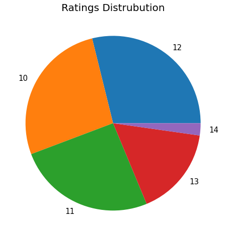

```python
# creating pie chart
plt.title('Ratings Distrubution', size = 20)
tec_df['rating_numerator'].value_counts().plot(kind = 'pie', figsize = (8,8), fontsize = 15)
plt.ylabel('')
plt.savefig('ratings.jpg');
```

#### Analysis:

Now that the data falls in the 10/10 to 15/10 rule, it looks like the rating that was given the most was a 12/10. There is only a small subsection of dogs who received higher than a 13/10, this also poses the question, are ratings a driving factor in the favorites/retweets correlation? Either way, it looks like there are a lot of good heckin' doggos in this dataset!